# Deseasonalization

2. Deseasonalization

Although simple exponential smoothing provides a basic framework for accounting for the influence of data points stretching further into the past, often times when dealing with time series data we will also need to be able to appropriately handle instances of seasonality. Since seasonality assumes that there are patterns of fluctuation with fixed length and predictable repetition, there are a number of ways to try and address it and account for its impacts through our modeling. More advanced and adaptive methods will be discussed in the following section, but one of the most straight forward and easily implemented approaches is known as seasonal adjustment or deseasonalization. The basic premise behind this method is that, once we have identified a seasonal trend through either inspection of the ACF/PACF plots or by directly observing the lineplot of the time series data, we can attempt to normalize and standardize the data by removing the increase or decrease in the response variable induced by the seasonal component. This process involves determining a multiplicative seasonal factor that will scale the values within that season relative to an expected, baseline value, and, to provide a grounded example of this issue and illustrate how the deseasonalization solution can be implemented in code, we will offer a demonstration using the ERCOT Hourly Load data which can be publicly accessed here: https://www.ercot.com/gridinfo/load/load_hist. This data tracks the hourly electrical energy consumption in Texas and can clearly be seen to contain both hourly and monthly seasonality.

The first step we will need to take is loading the necessary packages to manipulate and work with time series data.

```r
# load relevant packages
library(tidyverse)
library(readxl)
library(lubridate)
library(forecast)
```

With these packages in place, we can now load the data and configure it in the proper format; this primarily means cleaning the date-time feature of the data so that it can be correctly parsed by the tidyverse and forecasting functions.

```r
# load and combine the time series energy data
d1 <- read_excel('Native_Load_2017.xlsx')
d2 <- read_excel('Native_Load_2018.xlsx')
d3 <- read_excel('Native_Load_2019.xlsx')
d4 <- read_excel('Native_Load_2020.xlsx')
d5 <- read_excel('Native_Load_2021.xlsx')
d1$HourEnding <- d1$`Hour Ending`
d1 <- d1 %>% select(-`Hour Ending`)
d5$HourEnding <- d5$`Hour Ending`
d5 <- d5 %>% select(-`Hour Ending`)
data <- bind_rows(d1, d2, d3, d4, d5)
```

```r
# convert the dates to POSIXct format
data$HourEnding = mdy_hm(data$HourEnding)
data <- data %>% select(HourEnding, ERCOT)
data <- data %>% mutate(Month = month(data$HourEnding))
```

Once the data has been cleaned, we can start by visualizing the issue at hand using a simple lineplot.

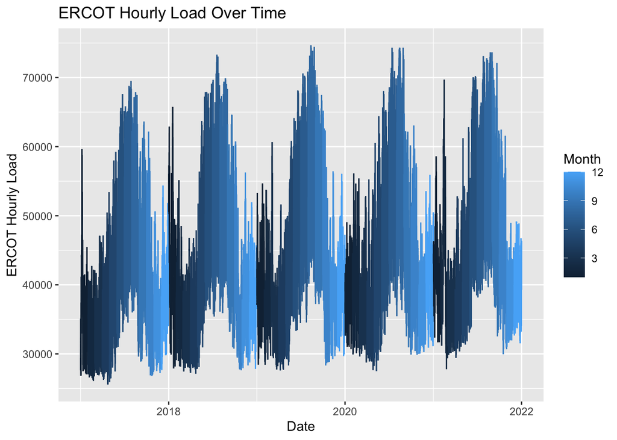

```r
# plot the energy consumption over time
ggplot(data, aes(x = HourEnding, y = ERCOT)) + geom_line(aes(color=Month)) + labs(title = 'ERCOT Hourly Load Over Time', x = 'Date', y = 'ERCOT Hourly Load')
```

From the plot above, it can be readily observed that there are indeed strong seasonal trends which seem to fluctuate roughly with the four yearly seasons as can be noted by the prominent peaks during the summer months and relative troughs during the fall and winter periods. At a more granular level, there are also potentially meaningful daily trends, but, before we can address this issue of layered or stacked seasonality, let us first try to address these more macroscopic seasonal trends.

Even though the four seasons may be the driving factor behind the observed seasonality in the data, we can also see that each month appears to be relatively stable across cycles as well, thus, in order to capture the seasonal fluctuations at a potentially finer and more precise level, we can treat each month as its own “season” and use these as the basis upon which we will perform the deseasonalization. In this setting, we now have that all $12$ months taken together form a single cycle, and, since we have hourly data with a yearly cycle, this means that we will need to account for a $24*365 = 8760$ period seasonal pattern.

To tease out the relative impact each month has on the energy consumption within it, we will need to first calculate the centered yearly moving average at each data point to determine what baseline value we would expect if there was no seasonal influence, and then we can divide the actual values by these expected values and average these derived ratios over the months to uncover what multiplicative factor each month has on its energy values.

To consider this process one component at a time, let us begin by computing the centered yearly moving average. Since our data is collected hourly, this makes it so that each value in the stream of centered moving averages should be computed by summing up all of the data points that lie within a half year radius about point of interest and then dividing this value by the total number of data points that occurred within that year long span. If the number of periods in our seasonal pattern were odd, this would make is so that we could simply center our summation window over the point of interest and calculate a single average to get the centered moving average at that location. Unfortunately, in our case, our period is $8760$ entries long which means the center of this interval would be at position $\frac{1+8760}{2} = 4380.5$. To remedy this issue and make it so that integer positions can be the center points of the moving average, we will need to take the mean of two averages rather than just a single average; explicitly, we will take one yearly moving average of the interval containing the point of interest at index $4380$ and another of the interval containing the point of interest at index $4381$, and, by finding the mean of these two yearly moving averages, we will get a good approximation of what the centered yearly moving average should be at the desired point.

Since we need a roughly half year buffer on either side of the first and last entries we compute the centered yearly moving averages at, this makes it so that we will not get baseline, expected values for the the entire domain of our data, but we should still have enough values per season to calculate reasonable seasonal factors.

With the baseline averaging scheme established, we can now implement that process and visualize the results.

```r
MovingAvg <- rep(NA, length(data$ERCOT))
for (i in ((24*365/2)+1):(length(data$ERCOT)-(24*365/2))) {
  MovingAvg[i] <- (sum(data$ERCOT[(i-(24*365/2)):(i+(24*365/2)-1)])/(24*365) + sum(data$ERCOT[(i-(24*365/2)+1):(i+(24*365/2))])/(24*365))/2
}
```

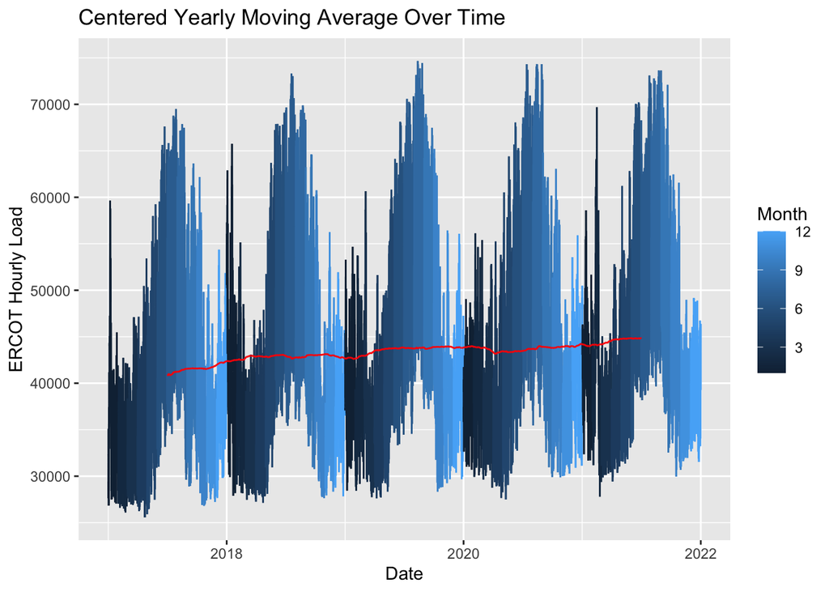

```r
data$MovingAvg <- MovingAvg
# plot the energy consumption over time
ggplot(data = data) + geom_line(aes(x = HourEnding, y = ERCOT, color = Month)) + geom_line(aes(x = HourEnding, y = MovingAvg), color = 'red') + labs(title = 'Centered Yearly Moving Average Over Time', x = 'Date', y = 'ERCOT Hourly Load')
```

As can be seen from the plot above, the centered yearly moving average has successfully smoothed out the seasonality effects within the data and provides us with a basis upon which we will be able to determine how each month influences the energy consumption within it. This can be achieved by dividing every data point by the expected, smoothed value and then grouping by and averaging these ratios over each month.

```r
SeasonalFactors <- data %>% group_by(Month) %>% summarise(SeasonalFactor = mean(ERCOT/MovingAvg, na.rm=TRUE))
data <- data %>% group_by(Month) %>% mutate(SeasonalFactor = mean(ERCOT/MovingAvg, na.rm=TRUE))
SeasonalFactors
```

```
## # A tibble: 12 × 2
##    Month SeasonalFactor
##    <dbl>          <dbl>
##  1     1          0.940
##  2     2          0.926
##  3     3          0.846
##  4     4          0.856
##  5     5          0.991
##  6     6          1.15
##  7     7          1.24
##  8     8          1.24
##  9     9          1.09
## 10    10          0.936
## 11    11          0.869
## 12    12          0.914
```

With these seasonal factors computed, we are able to now deseasonalize the data by dividing the original energy consumption values by their respective seasonal factors.

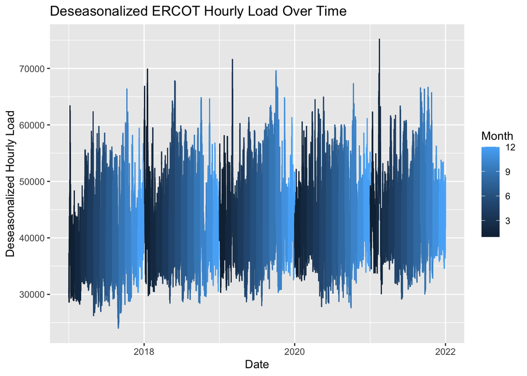

```r
data <- data %>% mutate(Deseasonalized = ERCOT/SeasonalFactor)
# plot the deseasonalized energy consumption over time
ggplot(data = data) + geom_line(aes(x = HourEnding, y = Deseasonalized, color = Month)) + labs(title = 'Deseasonalized ERCOT Hourly Load Over Time', x = 'Date', y = 'Deseasonalized Hourly Load')
```

Based on the plot above, we can see that the blatant monthly seasonality has been removed from the data, and we are now left with a set of time series data that can be more appropriately modeled using the previosuly discussed simple exponential smoothing techniques. To show this method of forecasting in action, we can use the ERCOT data from 2022 as a reference point against which we can compare the results of our predictive model.

We can load and clean this new validation data in the same manner as we did earlier, primarily making sure that the date-time data is in the correct format.

```r
future <- read_excel('Native_Load_2022.xlsx')
future$HourEnding <- future$`Hour Ending`
future <- future %>% select(-`Hour Ending`)
future$HourEnding = mdy_hm(future$HourEnding)
future <- future %>% select(HourEnding, ERCOT)
future <- future %>% mutate(Month = month(future$HourEnding))
```

Now that the data has been configured properly, we are able to use the ses() function from the forecast package to derive the future forecast estimates for the deseasonalized data over the the entire domain of the 2022 dataset. We can then plot the results to see how this approach has performed.

```r
fcast_model <- ses(data$Deseasonalized, h = nrow(future))
fcast <- as.data.frame(fcast_model)
future$DeseasonalizedForecast <- fcast$`Point Forecast`
future <- inner_join(future, SeasonalFactors, by = 'Month')
future <- future %>% mutate(Forecast = DeseasonalizedForecast*SeasonalFactor)
```

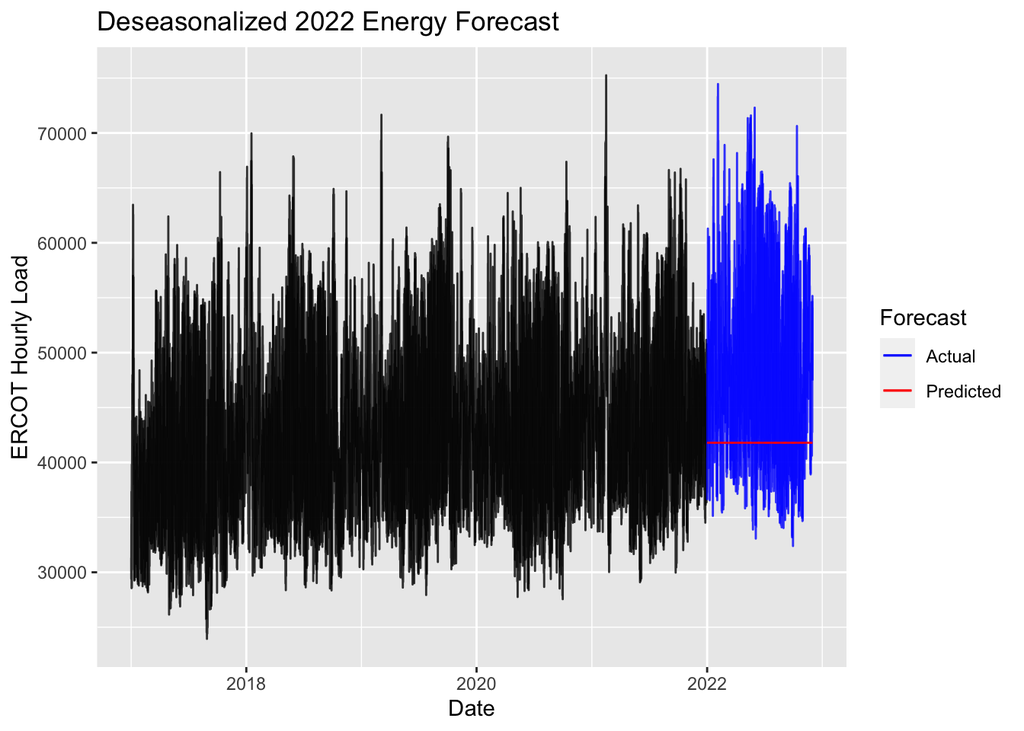

```r
ggplot() + geom_line(aes(x = data$HourEnding, y = data$Deseasonalized), alpha=0.8) + geom_line(aes(x = future$HourEnding, y = (future$ERCOT/future$SeasonalFactor), color = 'Actual'), alpha=0.8) + geom_line(aes(x = future$HourEnding, y = future$DeseasonalizedForecast, color = 'Predicted')) + labs(title = 'Deseasonalized 2022 Energy Forecast', x = 'Date', y = 'ERCOT Hourly Load', color = 'Forecast') + scale_color_manual(values = c('Actual' = 'blue', 'Predicted' = 'red'))
```

While the predicted forecast for the deseasonalized 2022 ERCOT hourly load data does not appear to match the actual values that well and tends to be consistently underestimating the true energy volumes, this is primarily due to the fact that the energy consumption at the end of 2021 was lower than normal, thus setting the point forecast for all future dates to be below where they normally might be. Although, this does not seem to be an ideal result, this is more of a circumstantial anomaly and unfortunate characteristic of the simple exponential smoothing model rather than an issue with the deseasonalization process, and, in fact, we have not even shown the final step in how we account for seasonality in this data yet. To truly appreciate the benefits of the deseasonalization method and see how well it does at handling the issue of seasonality in our forecasting models, we must now reseasonalize the data by multiplying all of the deseasonalized values and predicted forecasts by their respective seasonal scaling factors. This transformation back into the original frame of reference unveils how powerful this technique has actually beem.

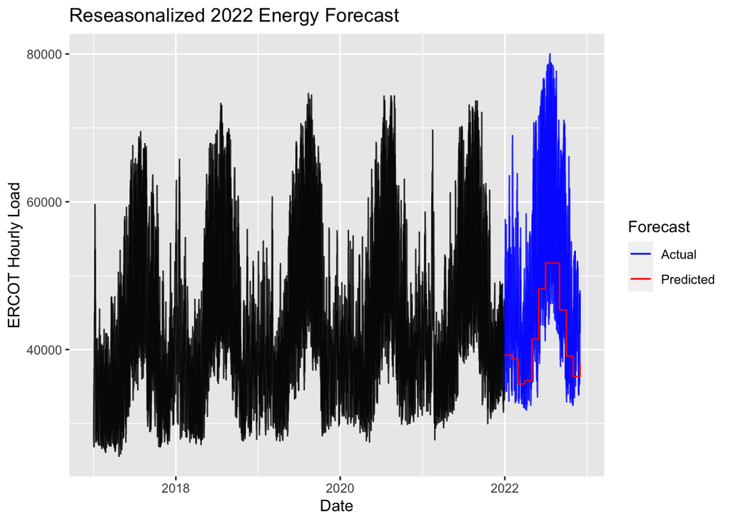

```r
ggplot() + geom_line(aes(x = data$HourEnding, y = data$ERCOT), alpha=0.8) + geom_line(aes(x = future$HourEnding, y = future$ERCOT, color = 'Actual'), alpha=0.8) + geom_line(aes(x = future$HourEnding, y = future$Forecast, color = 'Predicted')) + labs(title = 'Reseasonalized 2022 Energy Forecast', x = 'Date', y = 'ERCOT Hourly Load', color = 'Forecast') + scale_color_manual(values = c('Actual' = 'blue', 'Predicted' = 'red'))
```

The plot depicted above clearly shows how these seasonal factors produced through deseasonalization have allowed us to take into consideration the seasonal variation and influences on energy consumption and has made it so that our predicted forecast is now able to adhere far more closely to the actual values we observe in the world. While this method of deseasonalization has helped us take solid strides towards accounting for more factors that play a role in time series forecasting, there still a few crucial omissions in features it can handle: most notably, although this process has alleviated some of the seasonality concerns, it has done nothing to address the possible linear trends that are underlying the evolution of the data, and is also fails to manage the seasonal fluctuations in a fully adaptive and parameterized way. In order to model time-series data more precisely and accurately with all of its potentially nuanced characteristics and interactions, we will need to rely on more sophisticated and advanced methods, and the most prominent of these is the Holt-Winters method of exponential smoothing.